# 02 — Descriptive Analysis: Pre- and Post-COVID

## 8.5 Depression Before and After COVID

```r
# Calculate summary statistics for depression scores by COVID period.
phq_summary <- combined %>%
  group_by(Period) %>%
  summarise(
    N = sum(!is.na(PHQ)),
    Mean = mean(PHQ, na.rm = TRUE),
    Median = median(PHQ, na.rm = TRUE),
    SD = sd(PHQ, na.rm = TRUE)
  ) %>%
  mutate(
    across(
      where(is.numeric),
      ~ round(., 2)
    )
  )

knitr::kable(
  phq_summary,
  caption = "Depression Score Comparison"
)
```

Depression Score Comparison

| Period | N | Mean | Median | SD |
| --- | --- | --- | --- | --- |
| 2017-2018 Pre-COVID | 51639 | 1.89 | 1.78 | 0.67 |
| 2022-2023 Post-COVID | 41469 | 1.99 | 1.89 | 0.70 |

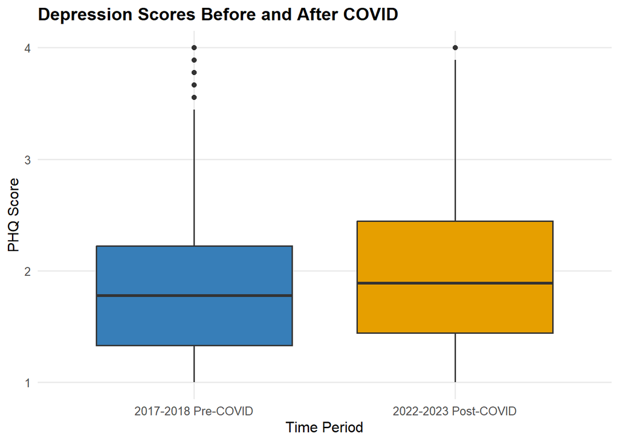

```r
# Visualize how depression-score distributions differ across COVID periods.
ggplot(
  filter(combined, !is.na(PHQ)),
  aes(
    x = Period,
    y = PHQ,
    fill = Period
  )
) +
  geom_boxplot() +
  scale_fill_manual(values = period_colors) +
  guides(fill = "none") +
  labs(
    title = "Depression Scores Before and After COVID",
    x = "Time Period",
    y = "PHQ Score"
  )
```

Depression scores were slightly higher after COVID, with the average PHQ score increasing from 1.89 before COVID to 1.99 after COVID.

## 8.6 Anxiety Before and After COVID

```r
# Calculate summary statistics for anxiety scores by COVID period.
gad_summary <- combined %>%
  group_by(Period) %>%
  summarise(
    N = sum(!is.na(GAD)),
    Mean = mean(GAD, na.rm = TRUE),
    Median = median(GAD, na.rm = TRUE),
    SD = sd(GAD, na.rm = TRUE)
  ) %>%
  mutate(
    across(
      where(is.numeric),
      ~ round(., 2)
    )
  )

knitr::kable(
  gad_summary,
  caption = "Anxiety Score Comparison"
)
```

Anxiety Score Comparison

| Period | N | Mean | Median | SD |
| --- | --- | --- | --- | --- |
| 2017-2018 Pre-COVID | 51065 | 1.98 | 1.86 | 0.79 |
| 2022-2023 Post-COVID | 41047 | 2.15 | 2.00 | 0.83 |

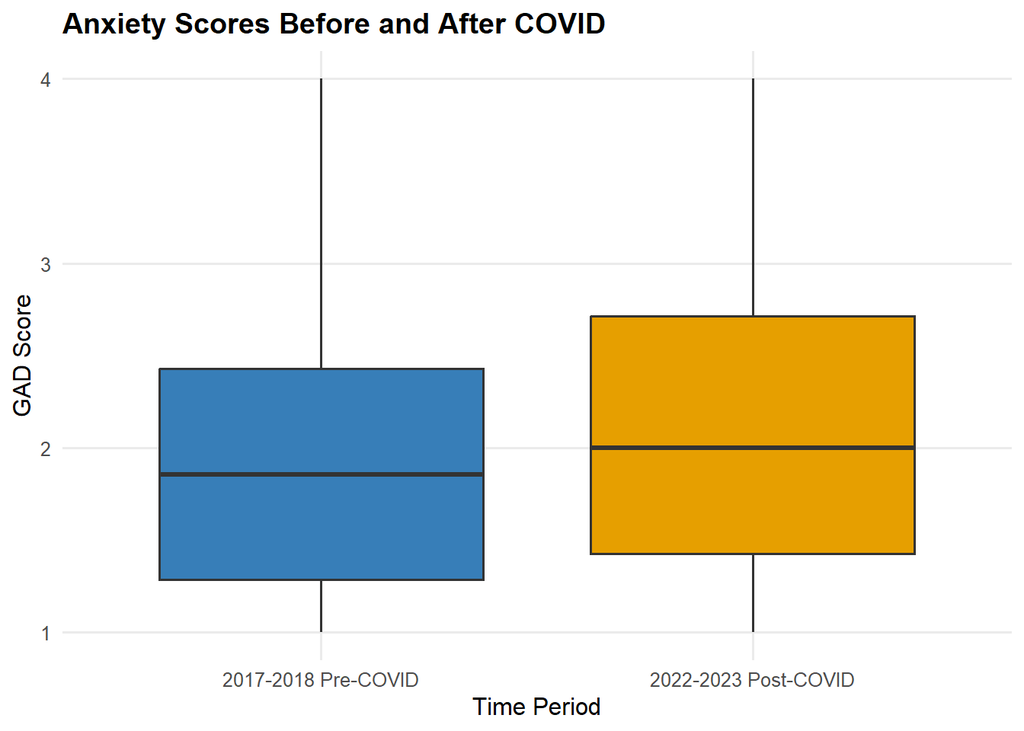

```r
# Visualize how anxiety-score distributions differ across COVID periods.
ggplot(
  filter(combined, !is.na(GAD)),
  aes(
    x = Period,
    y = GAD,
    fill = Period
  )
) +
  geom_boxplot() +
  scale_fill_manual(values = period_colors) +
  guides(fill = "none") +
  labs(
    title = "Anxiety Scores Before and After COVID",
    x = "Time Period",
    y = "GAD Score"
  )
```

Anxiety scores were higher after COVID, with the average GAD score increasing from 1.98 before COVID to 2.15 after COVID.

## 8.7 Depression by Gender Before and After COVID

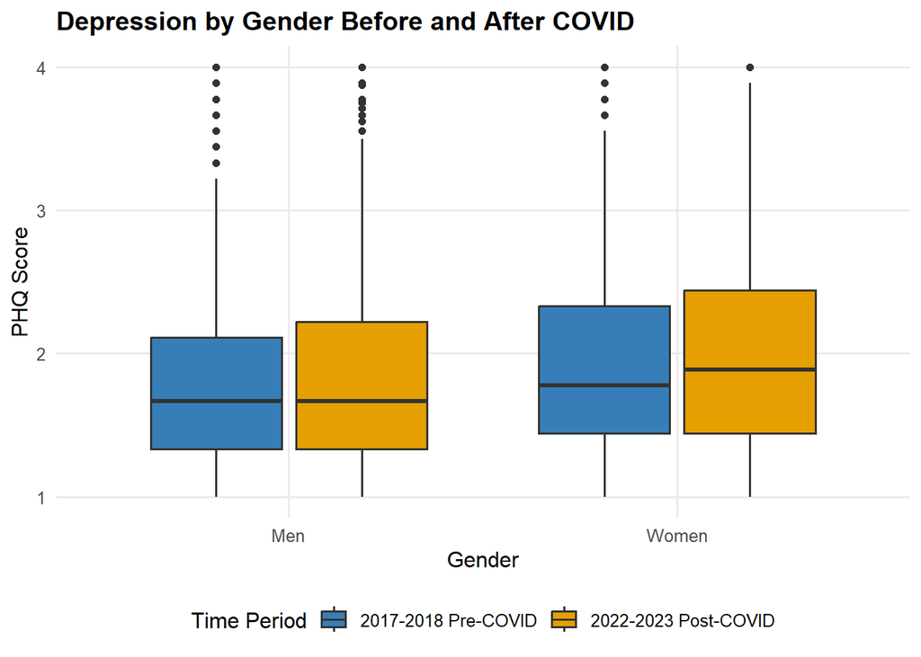

```r
# Compare depression scores by gender across COVID periods.
ggplot(
  filter(
    combined,
    !is.na(gender),
    !is.na(PHQ)
  ),
  aes(
    x = gender,
    y = PHQ,
    fill = Period
  )
) +
  geom_boxplot() +
  scale_fill_manual(values = period_colors) +
  labs(
    title = "Depression by Gender Before and After COVID",
    x = "Gender",
    y = "PHQ Score",
    fill = "Time Period"
  )
```

Women had higher depression scores than men in both time periods, and depression scores were generally higher after COVID.

## 8.8 Anxiety by Gender Before and After COVID

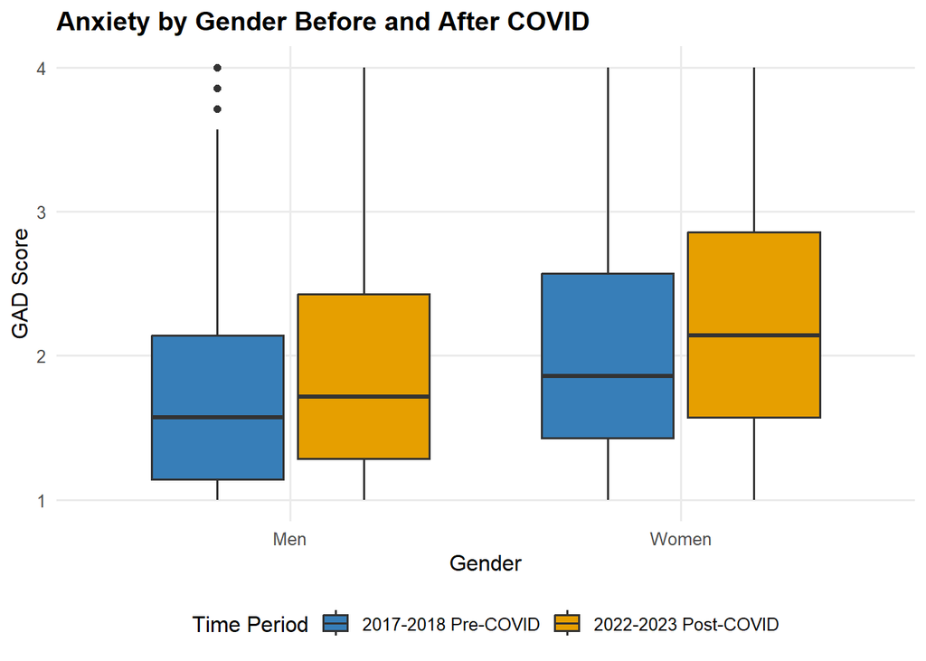

```r
# Compare anxiety scores by gender across COVID periods.
ggplot(
  filter(
    combined,
    !is.na(gender),
    !is.na(GAD)
  ),
  aes(
    x = gender,
    y = GAD,
    fill = Period
  )
) +
  geom_boxplot() +
  scale_fill_manual(values = period_colors) +
  labs(
    title = "Anxiety by Gender Before and After COVID",
    x = "Gender",
    y = "GAD Score",
    fill = "Time Period"
  )
```

Women had higher anxiety scores than men in both time periods, with anxiety scores generally increasing after COVID.

## 8.9 Depression by STEM Status Before and After COVID

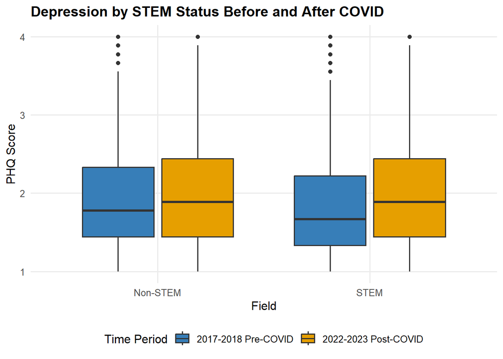

```r
# Compare depression scores by STEM status across COVID periods.
ggplot(
  filter(
    combined,
    !is.na(field),
    !is.na(PHQ)
  ),
  aes(
    x = field,
    y = PHQ,
    fill = Period
  )
) +
  geom_boxplot() +
  scale_fill_manual(values = period_colors) +
  labs(
    title = "Depression by STEM Status Before and After COVID",
    x = "Field",
    y = "PHQ Score",
    fill = "Time Period"
  )
```

The proportion of STEM and non-STEM students differed somewhat between the pre-COVID and post-COVID samples.

## 8.10 Anxiety by STEM Status Before and After COVID

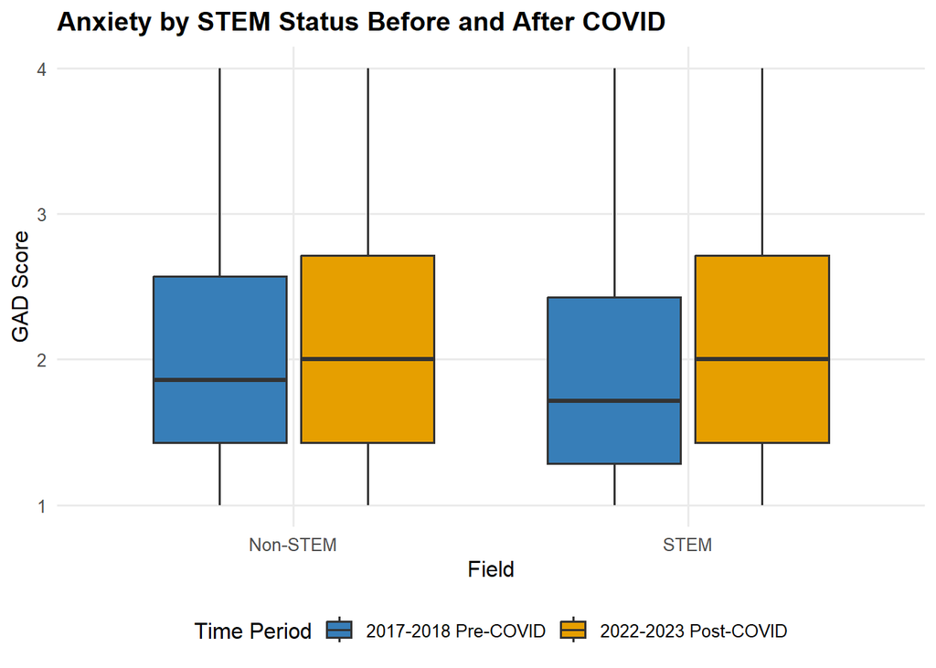

```r
# Compare anxiety scores by STEM status across COVID periods.
ggplot(
  filter(
    combined,
    !is.na(field),
    !is.na(GAD)
  ),
  aes(
    x = field,
    y = GAD,
    fill = Period
  )
) +
  geom_boxplot() +
  scale_fill_manual(values = period_colors) +
  labs(
    title = "Anxiety by STEM Status Before and After COVID",
    x = "Field",
    y = "GAD Score",
    fill = "Time Period"
  )
```

The proportion of STEM and non-STEM students differed somewhat between the pre-COVID and post-COVID samples.

# 9 Gender and STEM Together

```r
# Summarize depression and anxiety scores jointly by period, gender, and STEM status.
gender_stem_summary <- combined %>%
  filter(
    !is.na(gender),
    !is.na(field)
  ) %>%
  group_by(
    Period,
    gender,
    field
  ) %>%
  summarise(
    N = n(),
    Mean_PHQ = mean(PHQ, na.rm = TRUE),
    Mean_GAD = mean(GAD, na.rm = TRUE),
    .groups = "drop"
  )

gender_stem_summary
```

[output not shown]

## 9.1 Depression by Gender and STEM Status

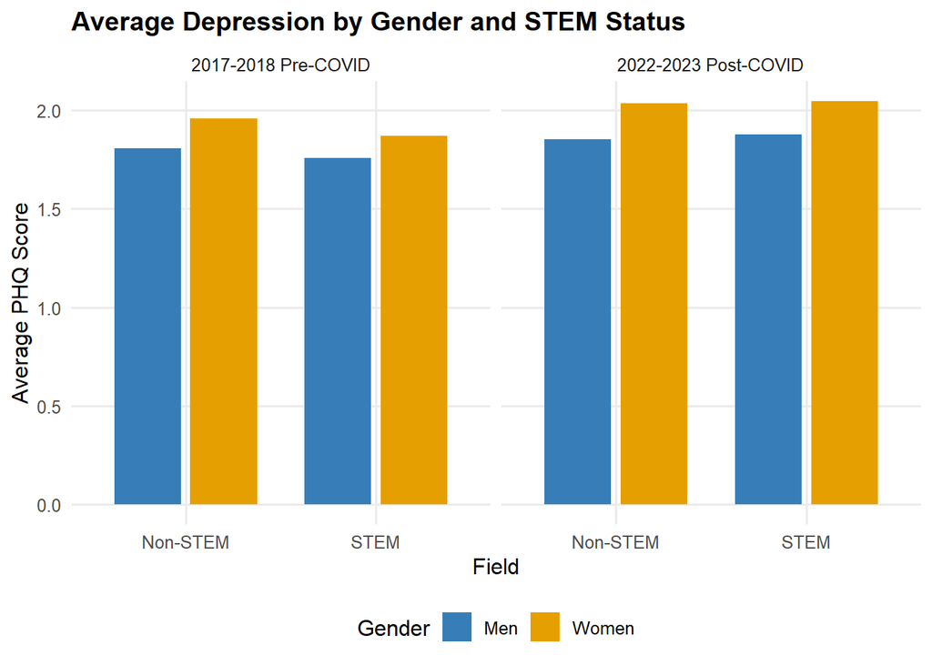

```r
# Visualize depression scores across gender and STEM groups in both periods.
ggplot(
  gender_stem_summary,
  aes(
    x = field,
    y = Mean_PHQ,
    fill = gender
  )
) +
  geom_col(
    position = position_dodge(width = 0.8),
    width = 0.7
  ) +
  facet_wrap(~Period) +
  scale_fill_manual(values = gender_colors) +
  labs(
    title = "Average Depression by Gender and STEM Status",
    x = "Field",
    y = "Average PHQ Score",
    fill = "Gender"
  )
```

The gender difference in depression appears in both STEM and non-STEM students, with women generally having higher average depression scores than men.

## 9.2 Anxiety by Gender and STEM Status

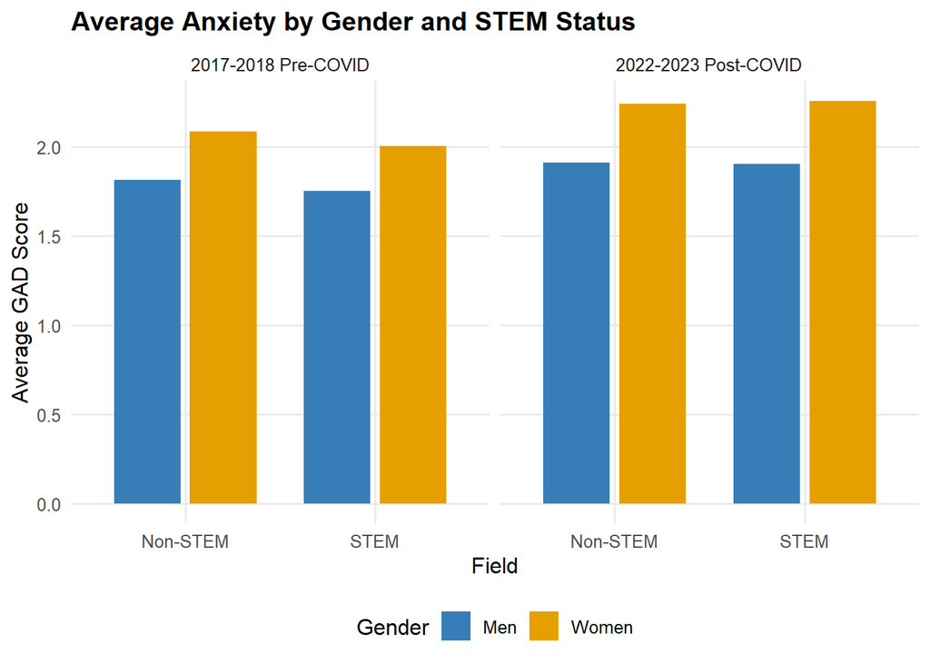

```r
# Visualize anxiety scores across gender and STEM groups in both periods.
ggplot(
  gender_stem_summary,
  aes(
    x = field,
    y = Mean_GAD,
    fill = gender
  )
) +
  geom_col(
    position = position_dodge(width = 0.8),
    width = 0.7
  ) +
  facet_wrap(~Period) +
  scale_fill_manual(values = gender_colors) +
  labs(
    title = "Average Anxiety by Gender and STEM Status",
    x = "Field",
    y = "Average GAD Score",
    fill = "Gender"
  )
```

Women generally had higher average anxiety scores than men in both STEM and non-STEM groups.

# 10 Financial Stress and Mental Health Comparison

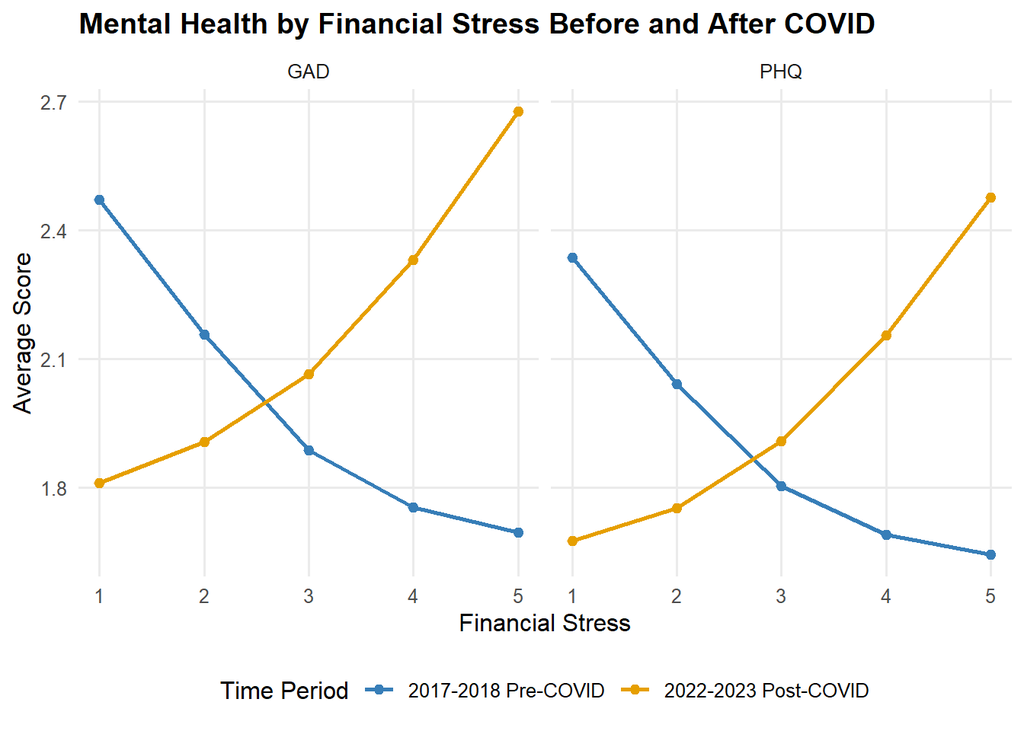

```r
# Summarize mental health outcomes by financial circumstances and COVID period.
financial_summary <- combined %>%
  group_by(
    Period,
    fincur.2
  ) %>%
  summarise(
    Mean_PHQ = mean(PHQ, na.rm = TRUE),
    Mean_GAD = mean(GAD, na.rm = TRUE),
    .groups = "drop"
  ) %>%
  pivot_longer(
    c(Mean_PHQ, Mean_GAD),
    names_to = "Measure",
    values_to = "Mean_Score"
  ) %>%
  mutate(
    Measure = recode(
      Measure,
      Mean_PHQ = "PHQ",
      Mean_GAD = "GAD"
    )
  )

ggplot(
  financial_summary,
  aes(
    x = fincur.2,
    y = Mean_Score,
    color = Period,
    group = Period
  )
) +
  geom_line(linewidth = 1) +
  geom_point(size = 2) +
  facet_wrap(~Measure) +
  scale_color_manual(values = period_colors) +
  labs(
    title = "Mental Health by Financial Stress Before and After COVID",
    x = "Financial Stress",
    y = "Average Score",
    color = "Time Period"
  )
```

# 11 Mental Health by Race Comparison

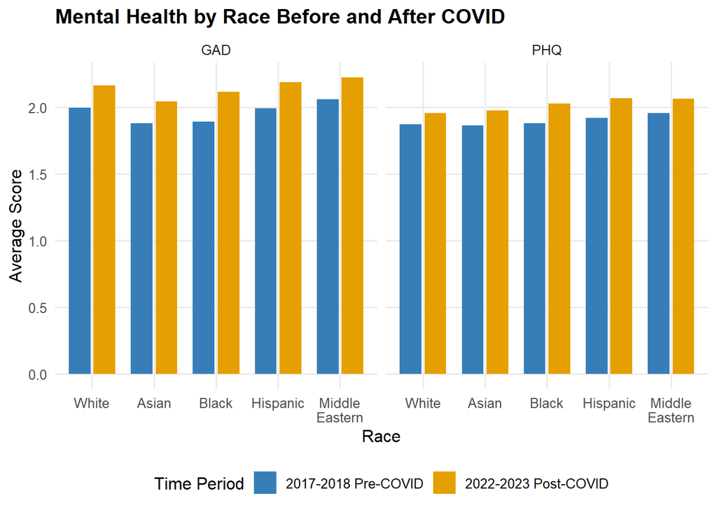

```r
# Summarize mental health outcomes by racial group and COVID period.
race_summary <- combined %>%
  group_by(
    Period,
    race.2
  ) %>%
  summarise(
    Mean_PHQ = mean(PHQ, na.rm = TRUE),
    Mean_GAD = mean(GAD, na.rm = TRUE),
    .groups = "drop"
  ) %>%
  pivot_longer(
    c(Mean_PHQ, Mean_GAD),
    names_to = "Measure",
    values_to = "Mean_Score"
  ) %>%
  mutate(
    Measure = recode(
      Measure,
      Mean_PHQ = "PHQ",
      Mean_GAD = "GAD"
    )
  )

ggplot(
  filter(
    race_summary,
    !is.na(race.2)
  ),
  aes(
    x = race.2,
    y = Mean_Score,
    fill = Period
  )
) +
  geom_col(
    position = position_dodge(width = 0.8),
    width = 0.7
  ) +
  facet_wrap(~Measure) +
  scale_fill_manual(values = period_colors) +
  scale_x_discrete(
    labels = c(
      "White",
      "Asian",
      "Black",
      "Hispanic",
      "Middle\nEastern"
    )
  ) +
  labs(
    title = "Mental Health by Race Before and After COVID",
    x = "Race",
    y = "Average Score",
    fill = "Time Period"
  )
```

Average depression and anxiety scores differed somewhat across racial groups and between the two time periods.

# 12 Mental Health by Year in School Comparison

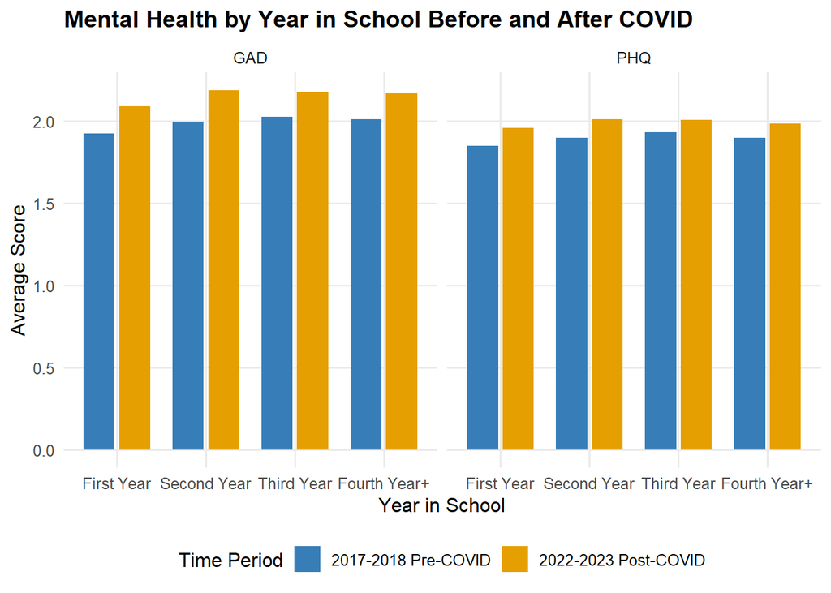

```r
# Summarize mental health outcomes by year in school and COVID period.
year_summary <- combined %>%
  group_by(
    Period,
    yr_sch.2
  ) %>%
  summarise(
    Mean_PHQ = mean(PHQ, na.rm = TRUE),
    Mean_GAD = mean(GAD, na.rm = TRUE),
    .groups = "drop"
  ) %>%
  pivot_longer(
    c(Mean_PHQ, Mean_GAD),
    names_to = "Measure",
    values_to = "Mean_Score"
  ) %>%
  mutate(
    Measure = recode(
      Measure,
      Mean_PHQ = "PHQ",
      Mean_GAD = "GAD"
    )
  )

ggplot(
  filter(
    year_summary,
    !is.na(yr_sch.2)
  ),
  aes(
    x = yr_sch.2,
    y = Mean_Score,
    fill = Period
  )
) +
  geom_col(
    position = position_dodge(width = 0.8),
    width = 0.7
  ) +
  facet_wrap(~Measure) +
  scale_fill_manual(values = period_colors) +
  scale_x_discrete(
    labels = c(
      "First Year",
      "Second Year",
      "Third Year",
      "Fourth Year+"
    )
  ) +
  labs(
    title = "Mental Health by Year in School Before and After COVID",
    x = "Year in School",
    y = "Average Score",
    fill = "Time Period"
  )
```

The distribution of students across years in school was somewhat different between the pre-COVID and post-COVID samples.

# 13 Depression and Anxiety Correlation Comparison

```r
# Compare the depression-anxiety correlation before and after COVID-19.
correlation_summary <- combined %>%
  group_by(Period) %>%
  summarise(
    PHQ_GAD_Correlation = cor(
      PHQ,
      GAD,
      use = "complete.obs"
    )
  ) %>%
  mutate(
    PHQ_GAD_Correlation = round(
      PHQ_GAD_Correlation,
      3
    )
  )

knitr::kable(
  correlation_summary,
  caption = "Correlation Between Depression and Anxiety"
)
```

Correlation Between Depression and Anxiety

| Period | PHQ_GAD_Correlation |
| --- | --- |
| 2017-2018 Pre-COVID | 0.750 |
| 2022-2023 Post-COVID | 0.742 |

The relationship between depression and anxiety stayed almost the same across the two time periods, with correlations of 0.75 before COVID and 0.74 after COVID.

# 14 Final EDA Summary

```r
# Create a final descriptive summary of the two samples and their mental health outcomes.
eda_summary <- combined %>%
  group_by(Period) %>%
  summarise(
    Students = n(),
    PHQ_N = sum(!is.na(PHQ)),
    Mean_PHQ = mean(PHQ, na.rm = TRUE),
    Median_PHQ = median(PHQ, na.rm = TRUE),
    SD_PHQ = sd(PHQ, na.rm = TRUE),
    GAD_N = sum(!is.na(GAD)),
    Mean_GAD = mean(GAD, na.rm = TRUE),
    Median_GAD = median(GAD, na.rm = TRUE),
    SD_GAD = sd(GAD, na.rm = TRUE),
    Mean_Age = mean(age, na.rm = TRUE),
    Mean_Financial_Stress = mean(
      fincur.2,
      na.rm = TRUE
    ),
    PHQ_GAD_Correlation = cor(
      PHQ,
      GAD,
      use = "complete.obs"
    )
  ) %>%
  mutate(
    across(
      where(is.numeric),
      ~ round(., 2)
    )
  )

knitr::kable(
  eda_summary,
  caption = "Overall EDA Summary"
)
```

Overall EDA Summary

| Period | Students | PHQ_N | Mean_PHQ | Median_PHQ | SD_PHQ | GAD_N | Mean_GAD | Median_GAD | SD_GAD | Mean_Age | Mean_Financial_Stress | PHQ_GAD_Correlation |
| --- | --- | --- | --- | --- | --- | --- | --- | --- | --- | --- | --- | --- |
| 2017-2018 Pre-COVID | 68427 | 51639 | 1.89 | 1.78 | 0.67 | 51065 | 1.98 | 1.86 | 0.79 | 22.96 | 2.88 | 0.75 |
| 2022-2023 Post-COVID | 43910 | 41469 | 1.99 | 1.89 | 0.70 | 41047 | 2.15 | 2.00 | 0.83 | 20.97 | 3.13 | 0.74 |

Overall, both depression and anxiety scores were higher in the post-COVID sample, while the relationship between depression and anxiety remained very similar across the two time periods.

# 15 EDA Conclusions

The exploratory analysis above allows us to compare the characteristics of the 2017-2018 and 2022-2023 samples before fitting statistical models.

The main outcomes of interest are depression and anxiety scores. Gender and STEM status are the main groups of interest, while age, race, year in school, and financial stress are also examined because they will be considered in the later modeling.

The next step will be to split the data into training, testing, and validation sets and begin the analytical modeling and validation stages of the data science pipeline.